# Econ 103L - Week 1 Minimum Working Example

Ryan Martin

January 8, 2018

# Discussion Problems

## Aside, Models and Interpretation.

In this class, there will be several models that will pop up repeatedly.

In this class, there will be several models that will pop up repeatedly.

1. Linear Model:
   $$y = \beta_1 + \beta_2x + e$$
   Predictive form: $\hat{y} = \hat{\beta}_1 + \hat{\beta_2} x$ and $\frac{d \hat{y}}{dx} = \hat{\beta_2}$. So, here $\hat{\beta_2}$ is exactly the slope.
2. log-linear Model:
   $$\log y = \beta_1 + \beta_2x + e$$
   Predictive Form: $\log \hat{y} = \hat{\beta}_1 + \hat{\beta_2}x.$ Note here that $\frac{\%\Delta \hat{y}}{\Delta x} \approx 100 \times \frac{d \hat{y}}{d x} \frac{1}{\hat{y}} = 100 \times \hat{\beta_2}$ and thus $100 \times \hat{\beta_2}$ can be interpreted as the percent change in predicted y for a 1 unit change in x (or $\hat{\beta_2}$ can be interpreted as the fraction change in y for a 1 unit change in x). In this case, $\hat{\beta_2}$ is called the semi-elasticity.
3. log transformed Model:
   $$y = \beta_1 + \beta_2 \log x + e$$
   Predictive Form: $\hat{y} = \hat{\beta}_1 + \hat{\beta_2} \log x$. Note here that $\frac{d \hat{y}}{dx} = \hat{\beta_2}/x$. Thus $\hat{\beta_2} = x \frac{d \hat{y}}{dx} \approx \frac{ \Delta \hat {y} }{\frac{1}{100} \% \Delta x} = 100 \times \frac{ \Delta \hat {y} }{ \% \Delta x}.$ That is, $\frac{1}{100}\hat{\beta_2}$ can be interpreted as the change in predicted y for a 1 percent change in x.
4. log-log:
   $$\log y = \beta_1 + \beta_2 \log x + e$$
   Predictive Form: $\log \hat{y} = \hat{\beta}_1 + \hat{\beta_2} \log x.$ Thus, $\frac{dy}{dx} \frac{1}{\hat{y}} = \hat{\beta_2} \frac{1}{x}$ which implies $\hat{\beta_2} = \frac{d \hat{y}}{dx} \frac{x}{y} \approx \frac{100}{100} \frac{\% \Delta y}{ \% \Delta x} = \frac{\% \Delta y}{ \% \Delta x}$ is (interpreted as) the elasticity of the predicted y with respect to the x variable. That is, it is the expected percent change in $y$ for a 1 percent change in $x$.

## 2.6

A soda vendor at Louisiana State University football games observes that more sodas are sold the warmer the temperature at game time is. Based on 32 home games covering five years, the vendor estimates the relationship between soda sales and temperature to be
$$\hat{y} = - 240 + 8x$$
where $y$ is the number of sodas she sells and x is the temperature in degrees Fahrenheit

### a

Interpret the estimated slope and intercept. Do the estimates make sense? Why or why not?

*Solution* Since it’s a line, the slope is just 8. (It is worth remembering for later that this could be done with calculus as well, especially in more complicated - nonlinear - relationships.) This says that for every single degree fahrenheit increase in temperature, our best estimate is that the vendor sells 8 more sodas. This has soda sales increasing with temperature, which is what was described above. The number does not seem crazy, although I have little experience with soda sales to know how reasonable it is.

### b

On a day when the temperature at game time is forecast to be $80^\circ$ F, predict how many sodas the vender will sell.

*Solution:*

```r
-240 + 8*80
```

```
## [1] 400
```

### c

Below what temperature are the predicted sales zero?

*Solution:* 30, because
$$0 = -240 + 8 \times \text{zero\_sale\_temp}$$
and solve

### d

Sketch a graph of the estimated regression line

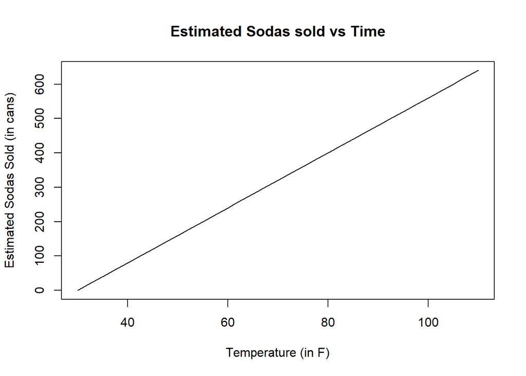

```r
x <-  30:110
y <-  -240 + 8*x
plot(x,y, xlab = "Temperature (in F)", ylab = "Estimated Sodas Sold (in cans)",
     main = "Estimated Sodas sold vs Time",type = 'l')
```

Note that very few of the actual data points (maybe none!) will fall on the line for most real-world datasets!

#### Quick note on running Stata

*Code graciously provided by Conor Foley. All mistakes are my own.*

*Note, without downloading (and paying for) Stata or using a school computer, you may be able to run it remotely from here:*

https://software.library.ucla.edu/Citrix/SoftwareWeb/

You have to play with it a little, but you can upload data files to the remote server and move code on your clipboard (i.e. that you have copied/ctrl +c) into the remote server. Use the navigation buttons on the top.

There are other options, but this one seems to be the easiest. It takes some effort to explore UCLA’s computing options, since different departments offer different resources. If you find a better solution, let me know.

## 2.15

### R Solution

How much does education affect wage rates? The data file $\texttt{cps4\_small.dat}$ contains 1000 observations on hourly wage rates, education and other variables from the 2008 Current Population Survey (CPS).

#### a

Obtain the summary statistics and histograms for the variables $WAGE$ and $EDUC$. Discuss the data characteristics.

*Solution*

Note that R can easily read in Stata files (`.dta`) with the right package (e.g. `haven`). Note that the # sign comments out a line.

```r
#You should set it to your own working directory
#Note that the \ slashes are the default, but you have to change these to
#either double backslashes or / as I did
# file location from computer: C:\Users\ryanj\Dropbox\TA\Econ 103\Winter 2018\Data
my_wd <- "C:/Users/ryanj/Dropbox/TA/Econ 103/Winter 2018/Data/s4poe_statadata"
my_file <- paste(my_wd, "cps4_small.dta", sep = "/")

#to read in stata files, need special package (many exist)
#install.packages('haven') #must run if haven't installed it yet
library(haven)
dat <- read_stata(my_file)
    #could also use
    #haven::read_stata(my_file)
    #for questions, type ?read_stata or ?haven::read_stata

#Take a look
#View(dat)



#################################################
#First looking at wage
#################################################

#refer to items with dollar sign
#these autocomplete, type the dollar sign then hit tab and choose from the
#dropdown menu. much easier than remembering the names
#these are the built in plots
summary(dat$wage) #5 number summary
```

```
##    Min. 1st Qu.  Median    Mean 3rd Qu.    Max.
##    1.97   11.25   17.30   20.62   25.63   76.39
```

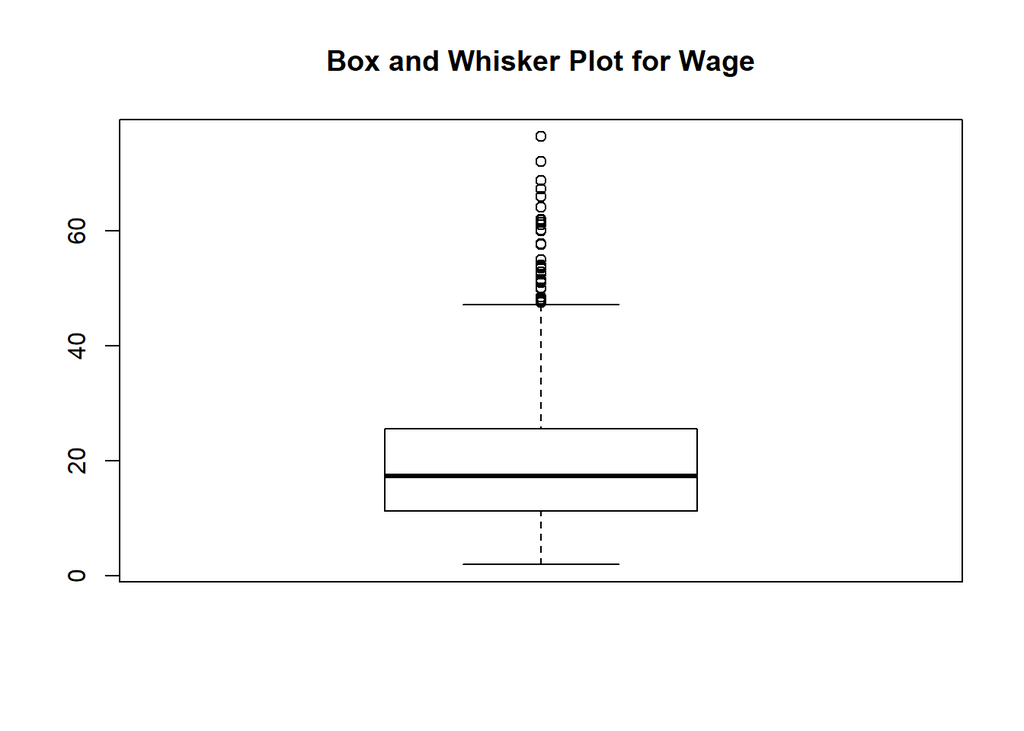

```r
boxplot(dat$wage, main = "Box and Whisker Plot for Wage")
```

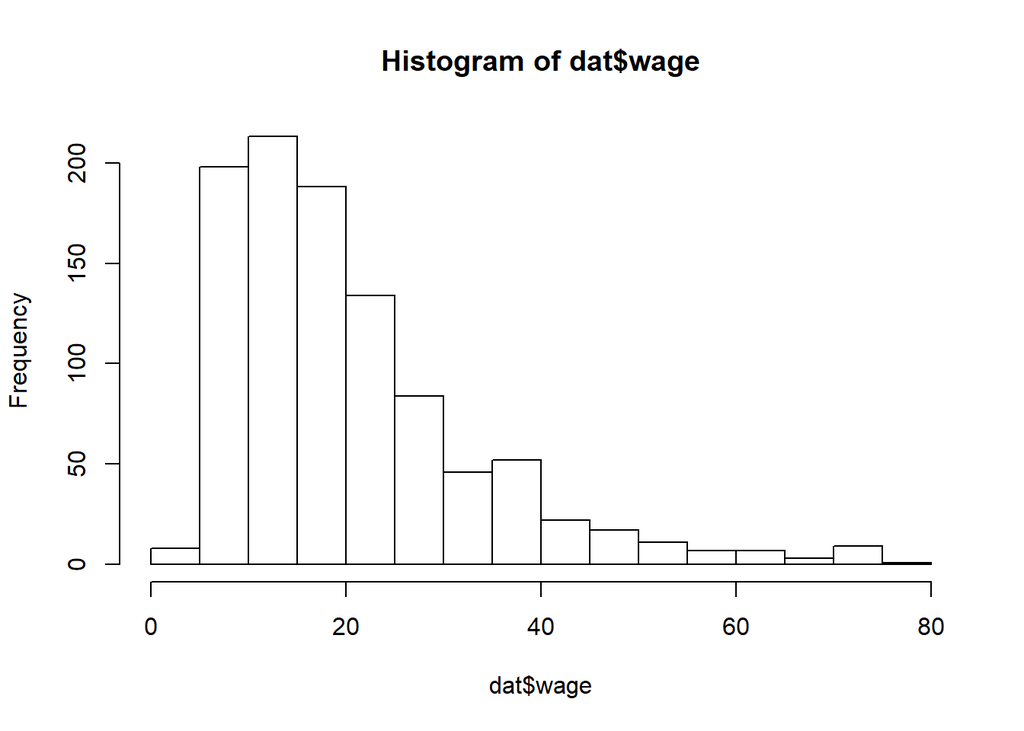

```r
hist(dat$wage)

#Note, ggplot2 has some fancier plots
#install.packages("ggplot2")
library(ggplot2)
```

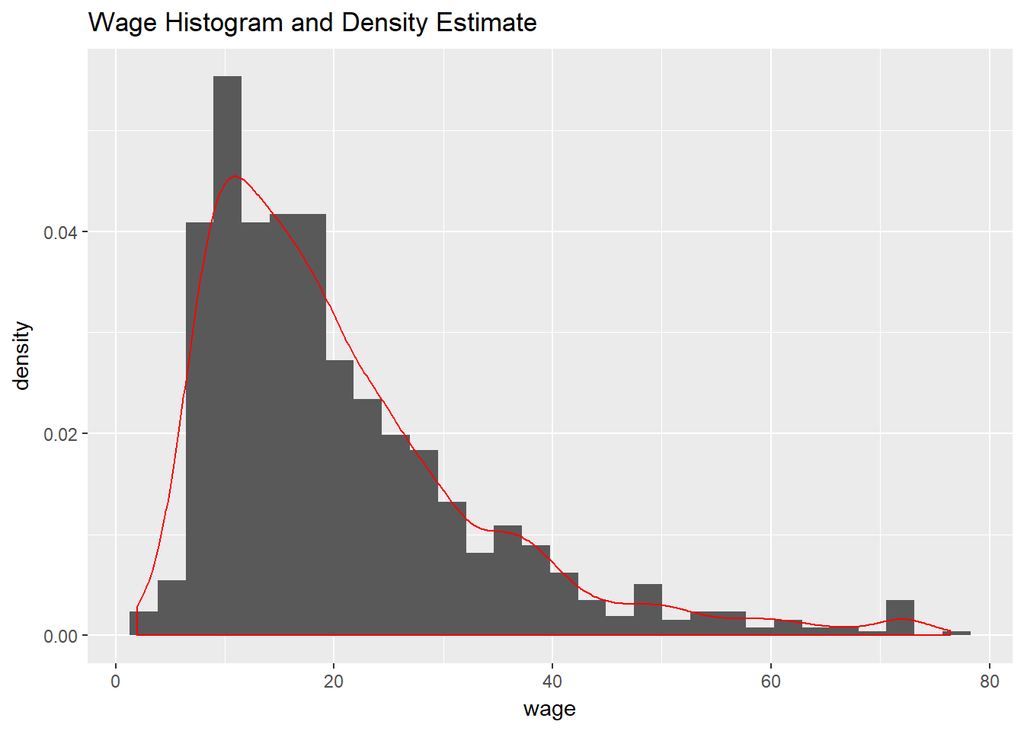

```r
ggplot(dat = dat, aes(wage, ..density..)) +
  geom_histogram() +
  geom_density(col = 'red') +
  ggtitle("Wage Histogram and Density Estimate")
```

```r
########################################################
#Education
#######################################################



summary(dat$educ) #5 number summary
```

```
##    Min. 1st Qu.  Median    Mean 3rd Qu.    Max.
##     0.0    12.0    13.0    13.8    16.0    21.0
```

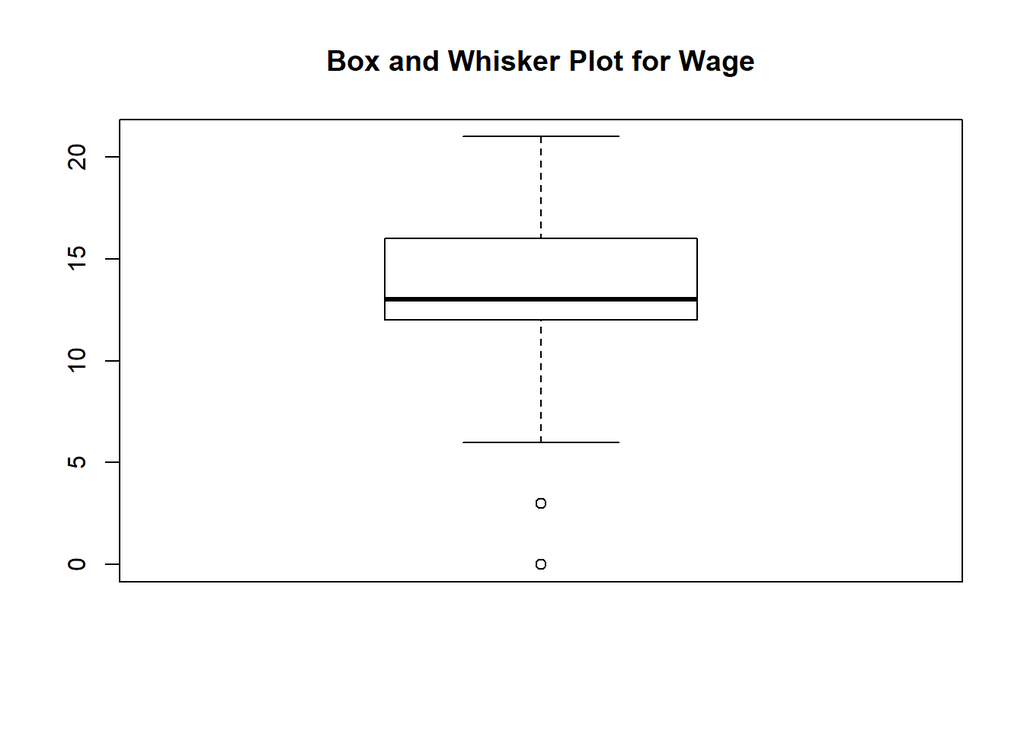

```r
boxplot(dat$educ, main = "Box and Whisker Plot for Wage")
```

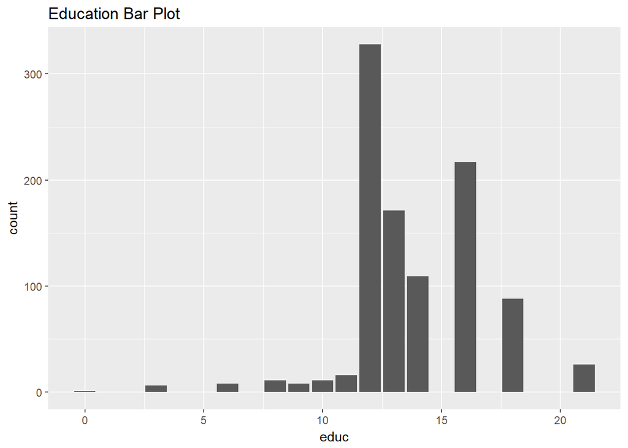

```r
## Education is discrete, so we go with a barplot
ggplot(dat = dat, aes(educ)) +
  geom_bar() +
  ggtitle("Education Bar Plot")
```

#### b

Estimate the linear regression $WAGE = \beta_1 + \beta_2EDUC + e$ and discuss the results

*Solution*

```r
attach(dat)
reg_out <- lm(wage ~ educ + 1)
summary(reg_out)
```

```
##
## Call:
## lm(formula = wage ~ educ + 1)
##
## Residuals:
##     Min      1Q  Median      3Q     Max
## -28.626  -7.816  -2.623   5.019  55.376
##
## Coefficients:
##             Estimate Std. Error t value Pr(>|t|)
## (Intercept)  -6.7103     1.9142  -3.506 0.000476 ***
## educ          1.9803     0.1361  14.548  < 2e-16 ***
## ---
## Signif. codes:  0 '***' 0.001 '**' 0.01 '*' 0.05 '.' 0.1 ' ' 1
##
## Residual standard error: 11.66 on 998 degrees of freedom
## Multiple R-squared:  0.175,  Adjusted R-squared:  0.1741
## F-statistic: 211.7 on 1 and 998 DF,  p-value: < 2.2e-16
```

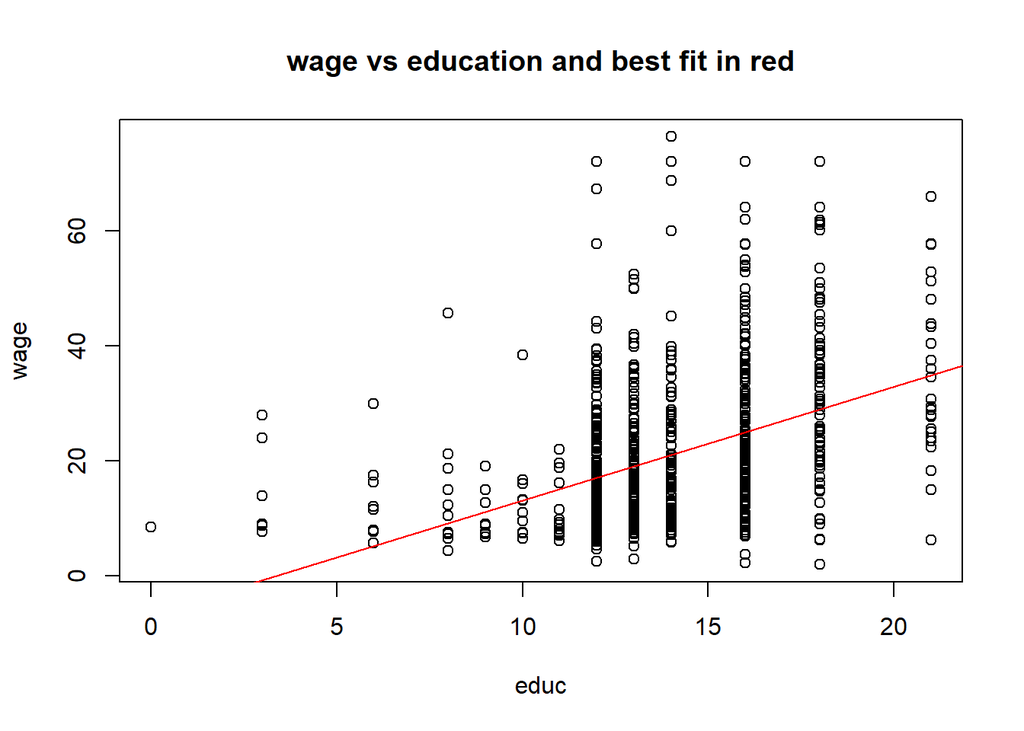

```r
#Plot using base functions
plot(educ, wage, main = "wage vs education and best fit in red")
abline(reg_out, col = "red")
```

```r
#make a little fancier with ggplot
race  <- rep("white", nrow(dat))
race[black == 1] <- "black"
race[asian == 1] <- "asian"

my_coef <- reg_out$coefficients
my_coef
```

```
## (Intercept)        educ
##   -6.710328    1.980288
```

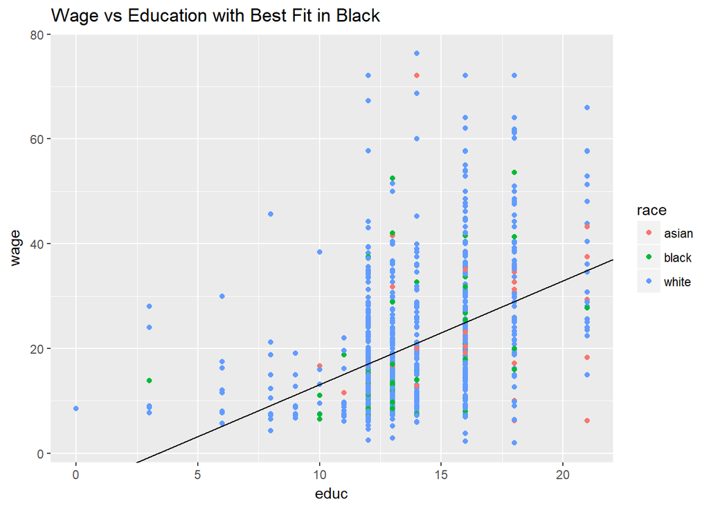

```r
dat2 <-  cbind(dat, race) #adds extra column to dat
ggplot(data = dat2, aes(x= educ, y = wage, color = race)) +
  geom_point() +
  geom_abline(aes(intercept = my_coef[1],
                  slope = my_coef[2] )) +
  ggtitle("Wage vs Education with Best Fit in Black")
```

#### c

Calculate the least squares residuals and plot them against $EDUC$. Are any patterns evident? If assumptions $SR1-SR5$ hold, should any patterns be evident in the least squares residuals?

*Solution*

Recall the assumptions (treating dependent variables as given, a.k.a. conditioning on it):

- SR1: The linear model is correct
- SR2: The errors are mean 0
- SR3: The errors are homoskedastic
- SR4: the errors are uncorrelated
- SR5: dependent variable (e.g. x) is treated as given but is not a constant (i.e. takes at least two values)
- SR6: (optional) errors are normally distributed

If the assumptions hold, there should be no change in the residual point spread as a function of education. (This is SR2 and SR3, in particular) It seems here that the residual variance does have some dependence on education. This suggests that our (linear) model may be the incorrect dependency.

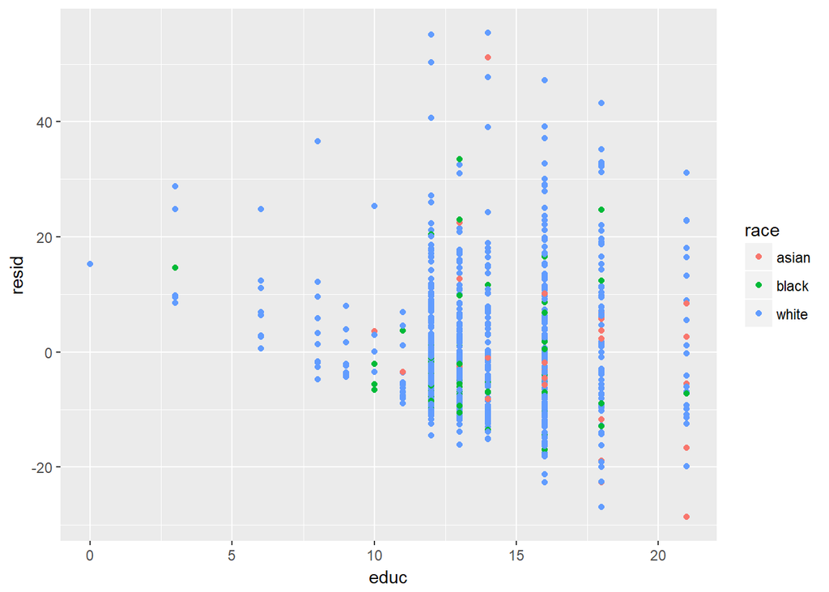

```r
resid <- reg_out$residuals
gender <- rep("male", nrow(dat))
gender[dat$female==1] <- "female"

dat3 <- cbind(dat2, resid,gender)
ggplot(data=dat3,aes(x = educ, y = resid, color = race) ) +
  geom_point()
```

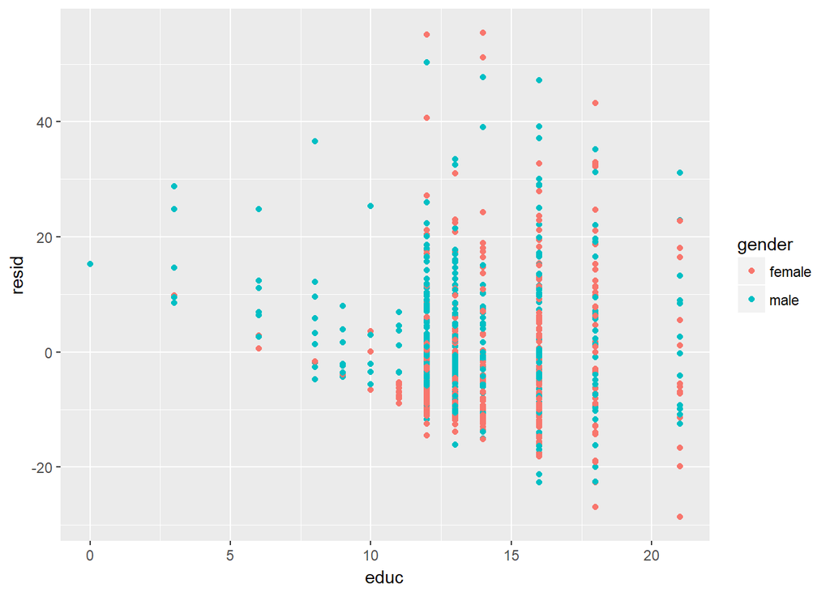

```r
#repeat by gender
ggplot(data=dat3,aes(x = educ, y = resid, color = gender) ) +
  geom_point()
```

#### d

Estimate separate regressions for males, females, blacks, and whites. Compare the results.

*Solution* There is a little ambiguity here. Is it just males, just females, just blacks and just whites. Or is it males and black, males and white, females and black, females and white? I will assume the first but I think both interpretations are reasonable

One point of comparison is the returns to education, which is the estimated slope. Note that males get lower returns to education than women and whites have lower returns to education than blacks. At the same time, we see that the intercept term, which corresponds to predicted wage with 0 education. Here, male is larger than female and white is larger than black.

**Note** We will learn how to do these later much more quickly and easily in one regression, with indicator variables and interaction effects.

```r
dat_male <- dat3[dat$female!=1,]
dat_female <- dat3[dat$female==1,]
dat_black <- dat3[dat$black==1,]
dat_white <- dat3[dat3$race=="white",]
  #could also use (dat$black!=1) & (dat$asian!=1)

reg_male <- lm(data = dat_male, wage ~ educ)
reg_female <- lm(data = dat_female, wage ~ educ)
reg_white <- lm(data = dat_white, wage ~ educ)
reg_black <- lm(data = dat_black, wage ~ educ)
summary(reg_male)
```

```
##
## Call:
## lm(formula = wage ~ educ, data = dat_male)
##
## Residuals:
##     Min      1Q  Median      3Q     Max
## -24.650  -7.558  -2.499   5.551  47.851
##
## Coefficients:
##             Estimate Std. Error t value Pr(>|t|)
## (Intercept)  -3.0545     2.4935  -1.225    0.221
## educ          1.8753     0.1814  10.336   <2e-16 ***
## ---
## Signif. codes:  0 '***' 0.001 '**' 0.01 '*' 0.05 '.' 0.1 ' ' 1
##
## Residual standard error: 11.55 on 484 degrees of freedom
## Multiple R-squared:  0.1808, Adjusted R-squared:  0.1791
## F-statistic: 106.8 on 1 and 484 DF,  p-value: < 2.2e-16
```

```r
summary(reg_female)
```

```
##
## Call:
## lm(formula = wage ~ educ, data = dat_female)
##
## Residuals:
##     Min      1Q  Median      3Q     Max
## -29.090  -6.710  -2.918   4.132  58.008
##
## Coefficients:
##             Estimate Std. Error t value Pr(>|t|)
## (Intercept) -14.1680     2.8957  -4.893 1.33e-06 ***
## educ          2.3575     0.2017  11.690  < 2e-16 ***
## ---
## Signif. codes:  0 '***' 0.001 '**' 0.01 '*' 0.05 '.' 0.1 ' ' 1
##
## Residual standard error: 11.35 on 512 degrees of freedom
## Multiple R-squared:  0.2107, Adjusted R-squared:  0.2091
## F-statistic: 136.7 on 1 and 512 DF,  p-value: < 2.2e-16
```

```r
summary(reg_black)
```

```
##
## Call:
## lm(formula = wage ~ educ, data = dat_black)
##
## Residuals:
##     Min      1Q  Median      3Q     Max
## -16.099  -6.303  -3.557   1.760  48.031
##
## Coefficients:
##             Estimate Std. Error t value Pr(>|t|)
## (Intercept) -15.0859     6.1693  -2.445   0.0161 *
## educ          2.4491     0.4531   5.405  3.8e-07 ***
## ---
## Signif. codes:  0 '***' 0.001 '**' 0.01 '*' 0.05 '.' 0.1 ' ' 1
##
## Residual standard error: 11.02 on 110 degrees of freedom
## Multiple R-squared:  0.2098, Adjusted R-squared:  0.2027
## F-statistic: 29.21 on 1 and 110 DF,  p-value: 3.803e-07
```

```r
summary(reg_white)
```

```
##
## Call:
## lm(formula = wage ~ educ, data = dat_white)
##
## Residuals:
##     Min      1Q  Median      3Q     Max
## -27.334  -7.944  -2.353   5.147  55.054
##
## Coefficients:
##             Estimate Std. Error t value Pr(>|t|)
## (Intercept)  -6.5507     2.0764  -3.155  0.00166 **
## educ          1.9919     0.1482  13.444  < 2e-16 ***
## ---
## Signif. codes:  0 '***' 0.001 '**' 0.01 '*' 0.05 '.' 0.1 ' ' 1
##
## Residual standard error: 11.67 on 843 degrees of freedom
## Multiple R-squared:  0.1766, Adjusted R-squared:  0.1756
## F-statistic: 180.8 on 1 and 843 DF,  p-value: < 2.2e-16
```

```r
new.dat <- data.frame(educ = c(12,14,16))
predict.lm(reg_male, newdata =new.dat)
```

```
##        1        2        3
## 19.44912 23.19972 26.95032
```

```r
predict.lm(reg_female, newdata =new.dat)
```

```
##        1        2        3
## 14.12218 18.83722 23.55226
```

```r
predict.lm(reg_white, newdata =new.dat)
```

```
##        1        2        3
## 17.35255 21.33641 25.32028
```

```r
predict.lm(reg_black, newdata =new.dat)
```

```
##        1        2        3
## 14.30277 19.20088 24.09900
```

#### e

Estimate the quadratic regression $WAGE = \alpha_1 + \alpha_2 EDUC^2 + e$ and discuss the results. Estimate the marginal effect of another year of education on wage for a person with 12 years of education and for a person with 14 years of education. Compare these values to the estimated marginal effect of education from the linear regression in part (b).

```r
attach(dat3)
quad_reg <- lm(wage ~ 1 + I(educ^2)) #note, must use I()!
    #because it's a formula object
summary(quad_reg)
```

```
##
## Call:
## lm(formula = wage ~ 1 + I(educ^2))
##
## Residuals:
##     Min      1Q  Median      3Q     Max
## -32.242  -7.665  -2.437   4.977  55.903
##
## Coefficients:
##             Estimate Std. Error t value Pr(>|t|)
## (Intercept) 6.082831   1.023161   5.945 3.82e-09 ***
## I(educ^2)   0.073489   0.004832  15.210  < 2e-16 ***
## ---
## Signif. codes:  0 '***' 0.001 '**' 0.01 '*' 0.05 '.' 0.1 ' ' 1
##
## Residual standard error: 11.57 on 998 degrees of freedom
## Multiple R-squared:  0.1882, Adjusted R-squared:  0.1874
## F-statistic: 231.3 on 1 and 998 DF,  p-value: < 2.2e-16
```

```r
quad_reg_coef <- quad_reg$coefficients
quad_reg_coef
```

```
## (Intercept)   I(educ^2)
##  6.08283101  0.07348906
```

```r
12*quad_reg_coef[2]
```

```
## I(educ^2)
## 0.8818687
```

```r
14*quad_reg_coef[2]
```

```
## I(educ^2)
##  1.028847
```

#### f

Plot the fitted linear model from part (b) and the fitted values from the quadratic model from part (e) in the same graph with the data on $WAGE$ and $EDUC$. Which model appears to fit the data better?

*Solution* The plots are below. The quadratic fit appears better.

*Note, there are actually many, many formal ways of testing which model fits better. The problem is called model selection*

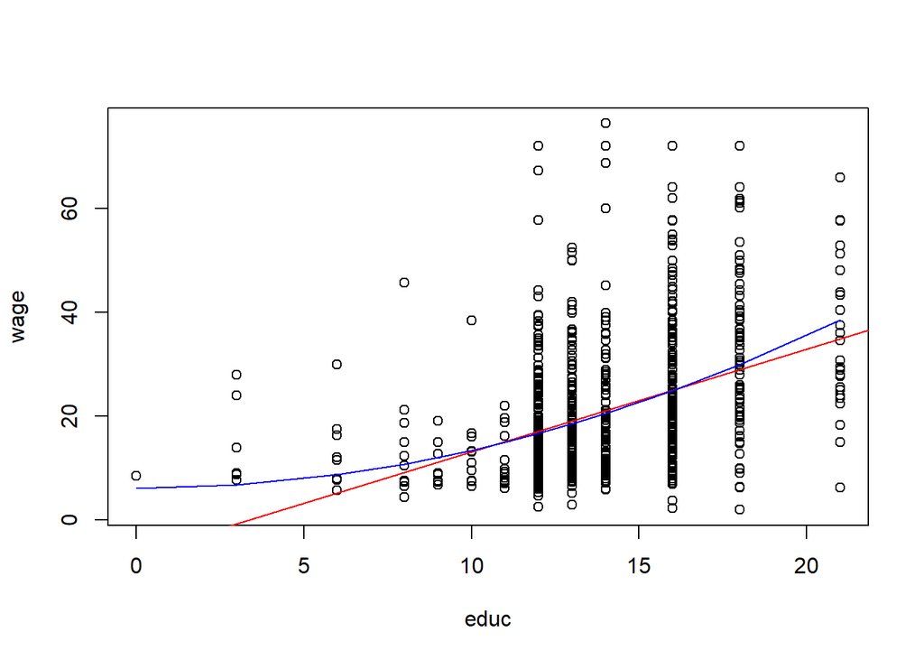

```r
quad_wage_est = quad_reg_coef[1] + sort(educ,decreasing = F)^2*quad_reg_coef[2]

plot(educ, wage)
abline(reg_out, col = "red")
lines(sort(educ,decreasing = F), quad_wage_est,col="blue")
```

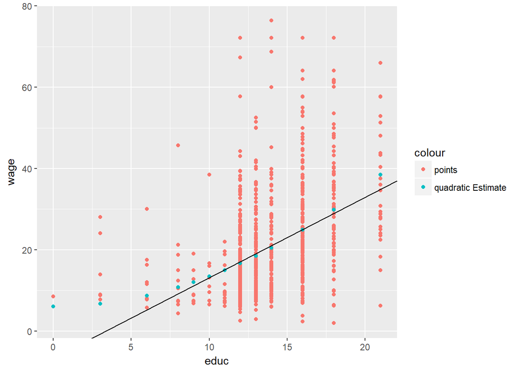

```r
#abline(quad_reg, col = "blue") #doesn't work

dat4 <- cbind(dat3,quad_wage_est)
ggplot(data = dat4) +
  geom_point(aes(x = educ, y = wage, color = "points")) +
  geom_point(aes(x = sort(educ,decreasing = F), y = quad_wage_est,color = 'quadratic Estimate')) +
  geom_abline(intercept = my_coef[1], slope = my_coef[2])
```

#### g

Construct a histogram of $ln(WAGE)$ (Note, log is usually natural log now too, even though in grade school it was the abbreviation for the base-10 log). Compare the shape of this histogram to that for $WAGE$ from part (a). Which appears more symmetric and bell-shaped?

*Solution* Histogram is below. This one is much more symmetric and bell-shaped.

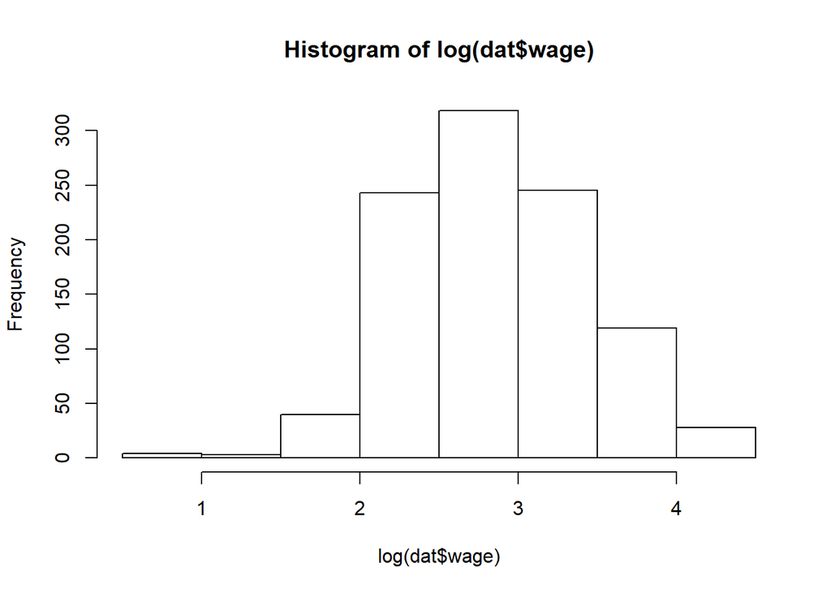

```r
hist(log(dat$wage))
```

#### h

*Solution* Using implicit differentation, taking the derivative of both sides with respect to education, we have
$$\frac{1}{\widehat{WAGE}} \frac{d \widehat{WAGE}}{d EDUC} = \hat{\gamma}_2$$
and thus the marginal effect of wage on education is $\widehat{WAGE} \times \hat{\gamma}_2$ Thus, our estimate is
$$\hat{gamma}_2 \widehat{WAGE} = \gamma_2 \times \exp(\gamma_1 + \gamma_2 EDUC)$$
So the marginal effect of 1 more year of schooling for a person with 12 years is or 14 years is 1.338 dollars per hour and 1.603. These numbers are a little higher than the earlier quadratic estimates but a little lower than the linear estimates.

```r
log_wage <- log(wage)
log_dat <- cbind(dat3,log_wage)
log_reg <- lm(dat = log_dat, log_wage ~ educ)
summary(log_reg)
```

```
##
## Call:
## lm(formula = log_wage ~ educ, data = log_dat)
##
## Residuals:
##      Min       1Q   Median       3Q      Max
## -2.55876 -0.39176  0.00699  0.36057  1.58413
##
## Coefficients:
##             Estimate Std. Error t value Pr(>|t|)
## (Intercept) 1.609444   0.086423   18.62   <2e-16 ***
## educ        0.090408   0.006146   14.71   <2e-16 ***
## ---
## Signif. codes:  0 '***' 0.001 '**' 0.01 '*' 0.05 '.' 0.1 ' ' 1
##
## Residual standard error: 0.5266 on 998 degrees of freedom
## Multiple R-squared:  0.1782, Adjusted R-squared:  0.1774
## F-statistic: 216.4 on 1 and 998 DF,  p-value: < 2.2e-16
```

```r
log_coef <- log_reg$coefficients

#marginal estimates at 12 and 14 years of education
log_coef[2] *exp(log_coef[1] + log_coef[2]* 12)
```

```
##     educ
## 1.337662
```

```r
log_coef[2] *exp(log_coef[1] + log_coef[2]* 14)
```

```
##     educ
## 1.602781
```